# EDA

```python
import numpy as np
import pandas as pd
import os
from glob import glob
%matplotlib inline
import matplotlib.pyplot as plt
import matplotlib.image as mpimg
import seaborn as sns
from random import sample
from itertools import chain
```

EDA is open-ended, and it is up to you to decide how to look at different ways to slice and dice your data. A good starting point is to look at the requirements for the FDA documentation in the final part of this project to guide (some) of the analyses you do.

This EDA should also help to inform you of how pneumonia looks in the wild. E.g. what other types of diseases it's commonly found with, how often it is found, what ages it affects, etc.

Note that this NIH dataset was not specifically acquired for pneumonia. So, while this is a representation of 'pneumonia in the wild,' the prevalence of pneumonia may be different if you were to take only chest x-rays that were acquired in an ER setting with suspicion of pneumonia.

Perform the following EDA:

- The patient demographic data such as gender, age, patient position,etc. (as it is available)
- The x-ray views taken (i.e. view position)
- The number of cases including:
  - number of pneumonia cases,
  - number of non-pneumonia cases
- The distribution of other diseases that are comorbid with pneumonia
- Number of disease per patient
- Pixel-level assessments of the imaging data for healthy & disease states of interest (e.g. histograms of intensity values) and compare distributions across diseases.

Note: use full NIH data to perform the first a few EDA items and use `sample_labels.csv` for the pixel-level assassements.

Also, **describe your findings and how will you set up the model training based on the findings.**

```python
## Loading NIH data
all_xray_df = pd.read_csv('/data/Data_Entry_2017.csv')
all_xray_df.sample(3)
```

|  | Image Index | Finding Labels | Follow-up # | Patient ID | Patient Age | Patient Gender | View Position | OriginalImage[Width | Height] | OriginalImagePixelSpacing[x | y] | Unnamed: 11 |
| --- | --- | --- | --- | --- | --- | --- | --- | --- | --- | --- | --- | --- |
| 28655 | 00007482_017.png | No Finding | 17 | 7482 | 60 | M | AP | 2500 | 2048 | 0.168 | 0.168 | NaN |
| 110687 | 00030162_002.png | Pneumothorax | 2 | 30162 | 15 | M | AP | 3056 | 2544 | 0.139 | 0.139 | NaN |
| 73633 | 00018103_013.png | Atelectasis\|Consolidation | 13 | 18103 | 19 | F | AP | 2500 | 2048 | 0.168 | 0.168 | NaN |

```python
#dividing the "Finding labels" column into multiple columns of individual diagnoses: all_labels
all_labels = np.unique(list(chain(*all_xray_df['Finding Labels'].map(lambda x: x.split('|')).tolist())))
all_labels = [x for x in all_labels if len(x)>0]
print('All Labels ({}): {}'.format(len(all_labels), all_labels))
for c_label in all_labels:
    if len(c_label)>1: # leave out empty labels
        all_xray_df[c_label] = all_xray_df['Finding Labels'].map(lambda finding: 1.0 if c_label in finding else 0)
all_xray_df.sample(3)
```

```
All Labels (15): ['Atelectasis', 'Cardiomegaly', 'Consolidation', 'Edema', 'Effusion', 'Emphysema', 'Fibrosis', 'Hernia', 'Infiltration', 'Mass', 'No Finding', 'Nodule', 'Pleural_Thickening', 'Pneumonia', 'Pneumothorax']
```

|  | Image Index | Finding Labels | Follow-up # | Patient ID | Patient Age | Patient Gender | View Position | OriginalImage[Width | Height] | OriginalImagePixelSpacing[x | ... | Emphysema | Fibrosis | Hernia | Infiltration | Mass | No Finding | Nodule | Pleural_Thickening | Pneumonia | Pneumothorax |
| --- | --- | --- | --- | --- | --- | --- | --- | --- | --- | --- | --- | --- | --- | --- | --- | --- | --- | --- | --- | --- | --- |
| 11922 | 00003109_000.png | Infiltration | 0 | 3109 | 50 | M | PA | 3056 | 2544 | 0.139 | ... | 0.0 | 0.0 | 0.0 | 1.0 | 0.0 | 0.0 | 0.0 | 0.0 | 0.0 | 0.0 |
| 16004 | 00004257_002.png | No Finding | 2 | 4257 | 80 | F | AP | 2500 | 2048 | 0.171 | ... | 0.0 | 0.0 | 0.0 | 0.0 | 0.0 | 1.0 | 0.0 | 0.0 | 0.0 | 0.0 |
| 75856 | 00018611_001.png | No Finding | 1 | 18611 | 33 | M | PA | 2992 | 2991 | 0.143 | ... | 0.0 | 0.0 | 0.0 | 0.0 | 0.0 | 1.0 | 0.0 | 0.0 | 0.0 | 0.0 |

3 rows × 27 columns

```python
len(all_labels)
```

```
15
```

```python
all_xray_df[all_labels].sum()/len(all_xray_df)
```

```
Atelectasis           0.103095
Cardiomegaly          0.024759
Consolidation         0.041625
Edema                 0.020540
Effusion              0.118775
Emphysema             0.022440
Fibrosis              0.015037
Hernia                0.002025
Infiltration          0.177435
Mass                  0.051570
No Finding            0.538361
Nodule                0.056466
Pleural_Thickening    0.030191
Pneumonia             0.012763
Pneumothorax          0.047289
dtype: float64
```

```
[Text(0, 0.5, 'Number of Images with Label')]
```

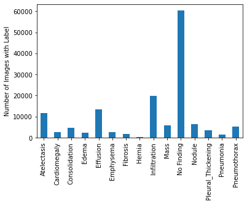

```python
#frequency of each diagnosis in the dataset
ax = all_xray_df[all_labels].sum().plot(kind='bar')
ax.set(ylabel = 'Number of Images with Label')
```

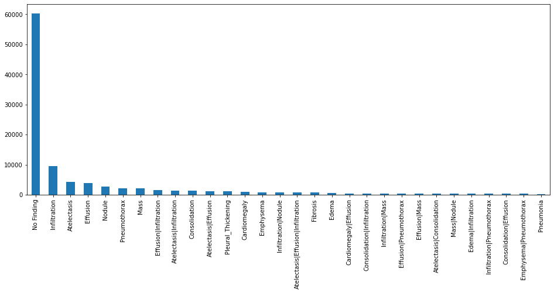

```python
#comorbid plot
plt.figure(figsize = (16,6))
all_xray_df['Finding Labels'].value_counts()[0:30].plot(kind='bar')
```

```python
#we take a subset that consists of patients positive for pneumonia
dfPneumonia = all_xray_df[all_xray_df.Pneumonia ==1]
dfPneumonia.head()
```

|  | Image Index | Finding Labels | Follow-up # | Patient ID | Patient Age | Patient Gender | View Position | OriginalImage[Width | Height] | OriginalImagePixelSpacing[x | ... | Emphysema | Fibrosis | Hernia | Infiltration | Mass | No Finding | Nodule | Pleural_Thickening | Pneumonia | Pneumothorax |
| --- | --- | --- | --- | --- | --- | --- | --- | --- | --- | --- | --- | --- | --- | --- | --- | --- | --- | --- | --- | --- | --- |
| 48 | 00000013_010.png | Effusion\|Pneumonia\|Pneumothorax | 10 | 13 | 60 | M | AP | 3056 | 2544 | 0.139 | ... | 0.0 | 0.0 | 0.0 | 0.0 | 0.0 | 0.0 | 0.0 | 0.0 | 1.0 | 1.0 |
| 126 | 00000032_012.png | Atelectasis\|Consolidation\|Edema\|Pneumonia | 12 | 32 | 55 | F | AP | 2500 | 2048 | 0.168 | ... | 0.0 | 0.0 | 0.0 | 0.0 | 0.0 | 0.0 | 0.0 | 0.0 | 1.0 | 0.0 |
| 253 | 00000056_000.png | Nodule\|Pneumonia | 0 | 56 | 76 | M | PA | 2500 | 2048 | 0.168 | ... | 0.0 | 0.0 | 0.0 | 0.0 | 0.0 | 0.0 | 1.0 | 0.0 | 1.0 | 0.0 |
| 276 | 00000061_012.png | Edema\|Effusion\|Infiltration\|Pleural_Thickening... | 12 | 61 | 77 | M | AP | 3056 | 2544 | 0.139 | ... | 0.0 | 0.0 | 0.0 | 1.0 | 0.0 | 0.0 | 0.0 | 1.0 | 1.0 | 0.0 |
| 279 | 00000061_015.png | Pneumonia | 15 | 61 | 77 | M | AP | 3056 | 2544 | 0.139 | ... | 0.0 | 0.0 | 0.0 | 0.0 | 0.0 | 0.0 | 0.0 | 0.0 | 1.0 | 0.0 |

5 rows × 27 columns

```
[Text(0, 0.5, 'Number of Images with Label')]
```

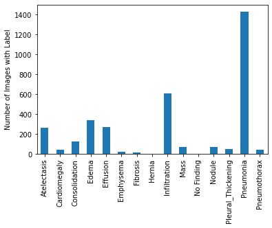

```python
#frequencies of other diagnoses in patients who are positive for pneumonia
ax = dfPneumonia[all_labels].sum().plot(kind='bar')
ax.set(ylabel = 'Number of Images with Label')
```

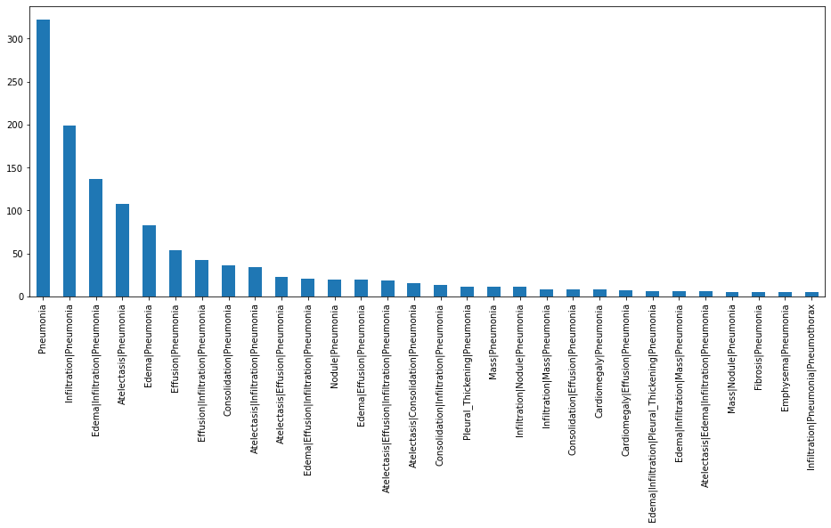

```python
#comorbid plot for patients with pneumonia
plt.figure(figsize = (16,6))
dfPneumonia['Finding Labels'].value_counts()[0:30].plot(kind='bar')
```

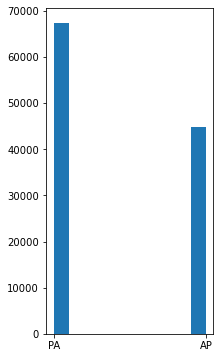

```python
#Patient position over the entire dataset
plt.figure(figsize = (3,6))
plt.hist(all_xray_df['View Position'])
```

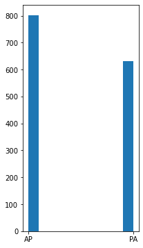

```python
#patient position in patients with pneumonia
plt.figure(figsize = (3,6))
plt.hist(all_xray_df[all_xray_df.Pneumonia ==1]['View Position'])
```

```python
len(all_xray_df['Patient Age']>120)
```

```
112120
```

```python
all_xray_df = all_xray_df[all_xray_df['Patient Age']<120]
```

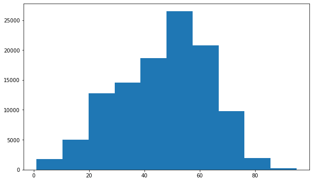

```python
#patient age distribution in the dataset
plt.figure(figsize=(10,6))
plt.hist(all_xray_df['Patient Age'])
```

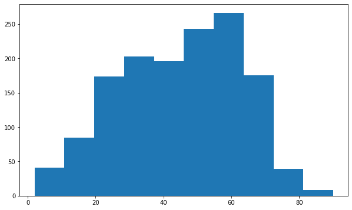

```python
#patient age distribution in patients with pneumonia
plt.figure(figsize=(10,6))
plt.hist(all_xray_df[all_xray_df.Pneumonia==1]['Patient Age'])
```

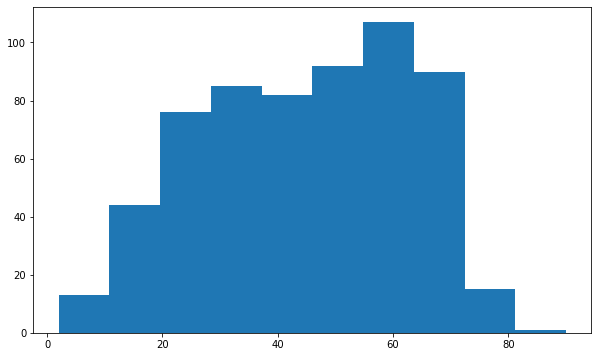

```python
#age distribution for patients with pneumonia and infiltration together
plt.figure(figsize=(10,6))
plt.hist(all_xray_df[all_xray_df.Pneumonia==1][all_xray_df.Infiltration==1]['Patient Age'])
```

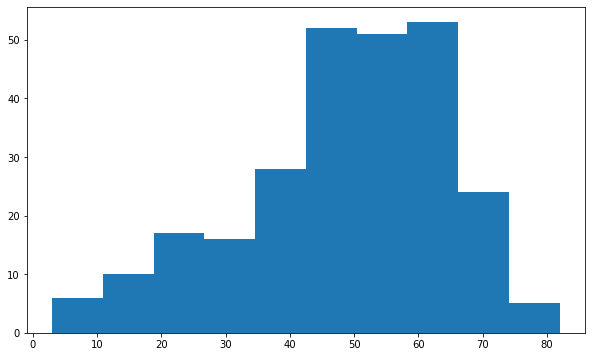

```python
#age distribution for patients with pneumonia and atelectasis together
plt.figure(figsize=(10,6))
plt.hist(all_xray_df[all_xray_df.Pneumonia==1][all_xray_df.Atelectasis==1]['Patient Age'])
```

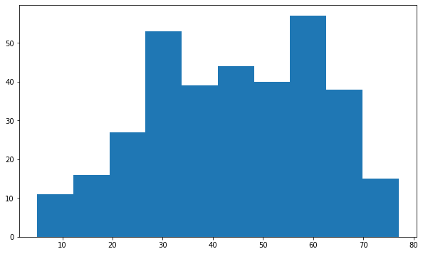

```python
#age distribution for patients with pneumonia and edema together
plt.figure(figsize=(10,6))
plt.hist(all_xray_df[all_xray_df.Pneumonia==1][all_xray_df.Edema==1]['Patient Age'])
```

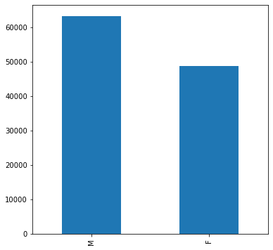

```python
#gender distribution for the dataset
plt.figure(figsize=(6,6))
all_xray_df['Patient Gender'].value_counts().plot(kind='bar')
```

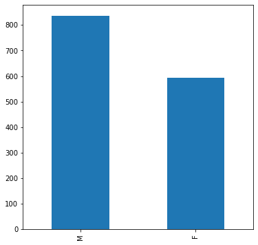

```python
#gender distribution for patients with pneumonia
plt.figure(figsize=(6,6))
all_xray_df[all_xray_df.Pneumonia == 1]['Patient Gender'].value_counts().plot(kind = 'bar')
```

```python
#taking a sample so that images may be read
data_sample = pd.read_csv('sample_labels.csv')
```